# hw01-donghan2

Liu, Donghan, Donghan2

Feb 2, 2018

```r
hw01_trn_data = read.csv("hw01-trn-data.csv")
hw01_tst_data = read.csv("hw01-tst-data.csv")
#install.packages('FNN')
#install.packages('kableExtra')
library(FNN)
library(rpart)
library(knitr)
library(kableExtra)
```

## Exercise 1 (Polynomial Models)

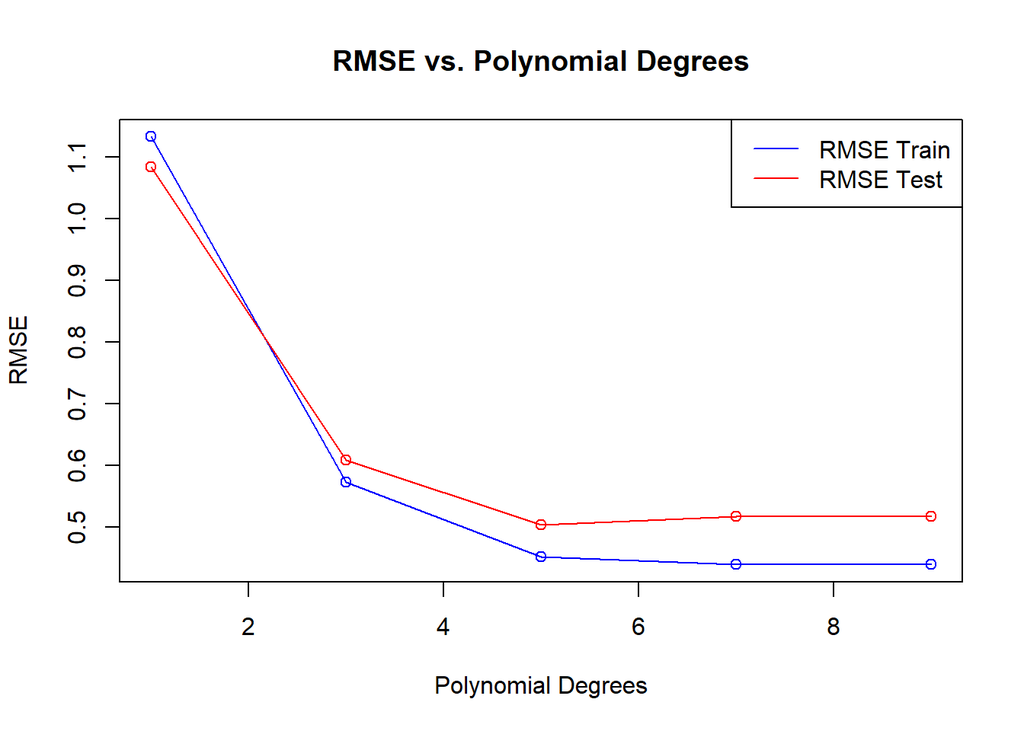

```r
data = hw01_trn_data
fit1 = lm(y ~ poly(x, 1),data = data)
fit3 = lm(y ~ poly(x, 3),data = data)
fit5 = lm(y ~ poly(x, 5),data = data)
fit7 = lm(y ~ poly(x, 7),data = data)
fit9 = lm(y ~ poly(x, 9),data = data)
rmsepoly = function(data,data1){
  calc_rmse = function(actual, predicted) {
    sqrt(mean((actual - predicted) ^ 2))
  }
  predict1 = predict(fit1,data1)
  predict3 = predict(fit3,data1)
  predict5 = predict(fit5,data1)
  predict7 = predict(fit7,data1)
  predict9 = predict(fit9,data1)

  predict0 = data.frame(predict1=predict1,predict3=predict3,predict5=predict5,predict7=predict7,predict9=predict9)
  rmse1 = c()
  for (i in 1:5){
    rmse1[i] = calc_rmse(data1$y,predict0[i])
  }
  return (rmse1)
}

plot(x = seq(1,9,2), y = rmsepoly(data = hw01_trn_data, data1 = hw01_trn_data),xlab = 'Polynomial Degrees',ylab = 'RMSE',main = 'RMSE vs. Polynomial Degrees',col = 'blue')
lines(x = seq(1,9,2), y = rmsepoly(data = hw01_trn_data, data1 = hw01_trn_data),col = 'blue')

points(x = seq(1,9,2), y = rmsepoly(data = hw01_trn_data, data1 = hw01_tst_data),col = 'red')
lines(x = seq(1,9,2), y = rmsepoly(data = hw01_trn_data, data1 = hw01_tst_data),col = 'red')

legend('topright',legend = c("RMSE Train","RMSE Test"),col = c('blue','red'),lty = 1)
```

## Exercise 2 (KNN Models)

```r
rmseknn= function(data,data1){
  calc_rmse = function(actual, predicted) {
    sqrt(mean((actual - predicted) ^ 2))
  }

  fit1 = knn.reg(train = data["x"], test = data1["x"], y = data["y"], k =  1)$pred
  fit11 = knn.reg(train = data["x"], test = data1["x"], y = data["y"], k =  11)$pred
  fit21 = knn.reg(train = data["x"], test = data1["x"], y = data["y"], k =  21)$pred
  fit31 = knn.reg(train = data["x"], test = data1["x"], y = data["y"], k =  31)$pred
  fit41 = knn.reg(train = data["x"], test = data1["x"], y = data["y"], k =  41)$pred

  predict = data.frame(fit1,fit11,fit21,fit31,fit41)
  rmse1 = c()
  for (i in 1:5){
    rmse1[i] = calc_rmse(data1['y'],predict[i])
  }
  return (rmse1)
}

table = data.frame(K =
             c(1,11,21,31,41),RMSE_Train = rmseknn(hw01_trn_data,hw01_trn_data),RMSE_Test = rmseknn(hw01_trn_data,hw01_tst_data))

kable_styling(kable(table, format = "html", digits = 2), full_width = FALSE)
```

| K | RMSE_Train | RMSE_Test |
| --- | --- | --- |
| 1 | 0.00 | 0.72 |
| 11 | 0.50 | 0.56 |
| 21 | 0.72 | 0.63 |
| 31 | 0.84 | 0.72 |
| 41 | 0.95 | 0.83 |

## Exercise 3 (Tree Models)

```r
rmsetree = function(data,data1){
  calc_rmse = function(actual, predicted) {
    sqrt(mean((actual - predicted) ^ 2))
  }
  fit0 = rpart(y ~ x, data = data, control = rpart.control(cp = 0, minsplit = 2))
  fit0001 = rpart(y ~ x, data = data, control = rpart.control(cp = 0.001, minsplit = 2))
  fit001 = rpart(y ~ x, data = data, control = rpart.control(cp = 0.01, minsplit = 2))
  fit01 = rpart(y ~ x, data = data, control = rpart.control(cp = 0.1, minsplit = 2))
  fit1 = rpart(y ~ x, data = data, control = rpart.control(cp = 1, minsplit = 2))

  predict0 = predict(fit0,data1['x'])
  predict0001 = predict(fit0001,data1['x'])
  predict001 = predict(fit001,data1['x'])
  predict01 = predict(fit01,data1['x'])
  predict1 = predict(fit1,data1['x'])

  predict = data.frame(predict0,predict0001,predict001,predict01,predict1)
  rmse1 = c()
  for (i in 1:5){
    rmse1[i] = calc_rmse(data1['y'],predict[i])
  }
  return (rmse1)
}

tabletree = data.frame(Cp = c(0,0.001,0.01,0.1,1), RMSE_Train = rmsetree(hw01_trn_data,hw01_trn_data), RMSE_Test =
rmsetree(hw01_trn_data,hw01_tst_data))

kable_styling(kable(tabletree, format = "html", digits = 2), full_width = FALSE)
```

| Cp | RMSE_Train | RMSE_Test |
| --- | --- | --- |
| 0.00 | 0.00 | 0.72 |
| 0.00 | 0.19 | 0.68 |
| 0.01 | 0.43 | 0.61 |
| 0.10 | 0.65 | 0.70 |
| 1.00 | 1.19 | 1.05 |

## Exercise 4 (Visualizing Results)

Since the lower RMSE is, the predicted model is more accurate, so we would like to choose 5 as polynomial degrees for poly model, k = 11 as number of neighbors in KNN model, and cp = 0.01 for the tree models.

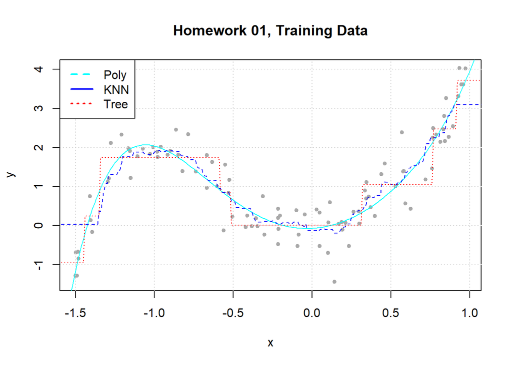

```r
plot(y ~ x, data = hw01_trn_data, col = "darkgrey", pch = 20,
     main = "Homework 01, Training Data")
grid()

temp_grid = data.frame(x = seq(from = min(hw01_trn_data$x) - 5, to = max(hw01_trn_data$x) + 5, by  = 0.01))

fit5 = lm(y ~ poly(x, 5),data = hw01_trn_data)
poly_pred_plot = predict(fit5,temp_grid)

fit41 = knn.reg(train = hw01_trn_data["x"], test = temp_grid["x"], y = hw01_trn_data["y"], k =  11)$pred

fit1 = rpart(y ~ x, data = hw01_trn_data, control = rpart.control(cp = 0.01, minsplit = 2))
predict1 = predict(fit1,temp_grid['x'])


lines(temp_grid$x,poly_pred_plot, col = 'cyan',lty = 1)
lines(temp_grid$x,fit41, col = 'blue',lty = 2)
lines(temp_grid$x,predict1, col = 'red',lty = 3)
legend("topleft", c("Poly", "KNN",'Tree'), lty = c(2, 1,3), lwd = 2, col = c("cyan", "blue",'red'),cex = 1)
```

## Exercise 5 (Concept Checks)

From the plot in exercise 4, we could see the model fitting of poly with degree of 5, KNN model with k = 11 and tree model with cp = 0.01. We will check the overfitting and underfitting for the rest of models.

a b.

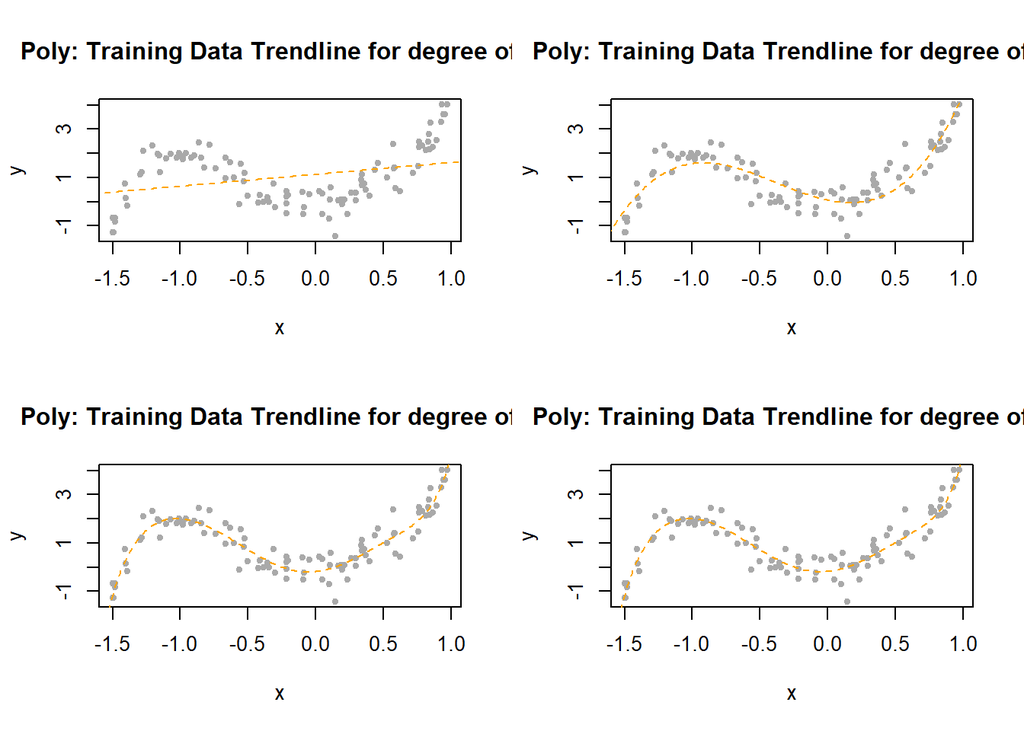

```r
poly_plot = function(i){
  temp_grid = data.frame(x = seq(from = min(hw01_trn_data$x) - 5, to = max(hw01_trn_data$x) + 5, by  = 0.01))
  fit = lm(y ~ poly(x, i),data = hw01_trn_data)
  poly_pred_plot = predict(fit,temp_grid)
  plot(y ~ x, data = hw01_trn_data, col = "darkgrey", pch = 20,main = gsub('this',i,"Poly: Training Data Trendline for degree of this"))
  lines(temp_grid$x,poly_pred_plot, col = 'orange',lty = 2)
}
par(mfrow = c(2, 2))
poly_plot(1)
poly_plot(3)
poly_plot(7)
poly_plot(9)
```

According to the above tables, when poly degree = 1 or 3, the trendline does not fit the original value well, so they are likely to have underfitting. 7 and 9 are likely be considered as overfitting.

c d.

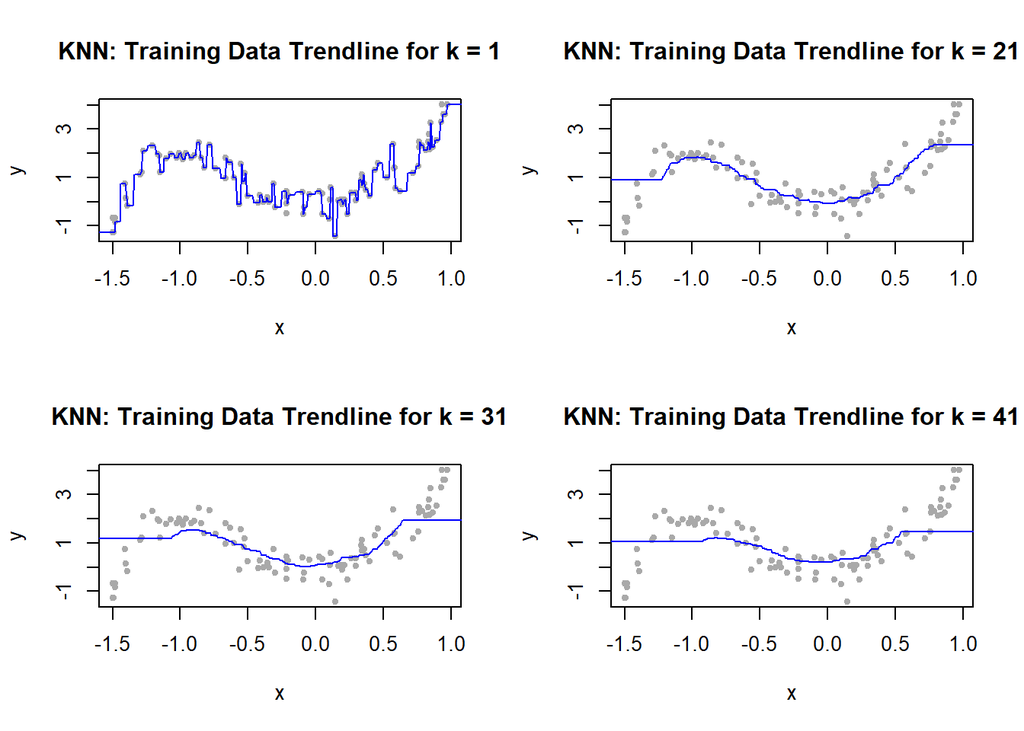

```r
knn_plot = function(k){
  temp_grid = data.frame(x = seq(from = min(hw01_trn_data$x) - 5, to = max(hw01_trn_data$x) + 5, by  = 0.01))
  fit = knn.reg(train = hw01_trn_data["x"], test = temp_grid["x"], y = hw01_trn_data["y"], k =  k)$pred
  plot(y ~ x, data = hw01_trn_data, col = "darkgrey", pch = 20,main = gsub('this',k,"KNN: Training Data Trendline for k = this"))
  lines(temp_grid$x,fit, col = 'blue',lty = 1)
}
par(mfrow = c(2, 2))
knn_plot(1)
knn_plot(21)
knn_plot(31)
knn_plot(41)
```

The above tables state that the model is overfitting when number of neighbors = 1 and underfitting when number of neighbors = 31 or 41 or 21.

e f.

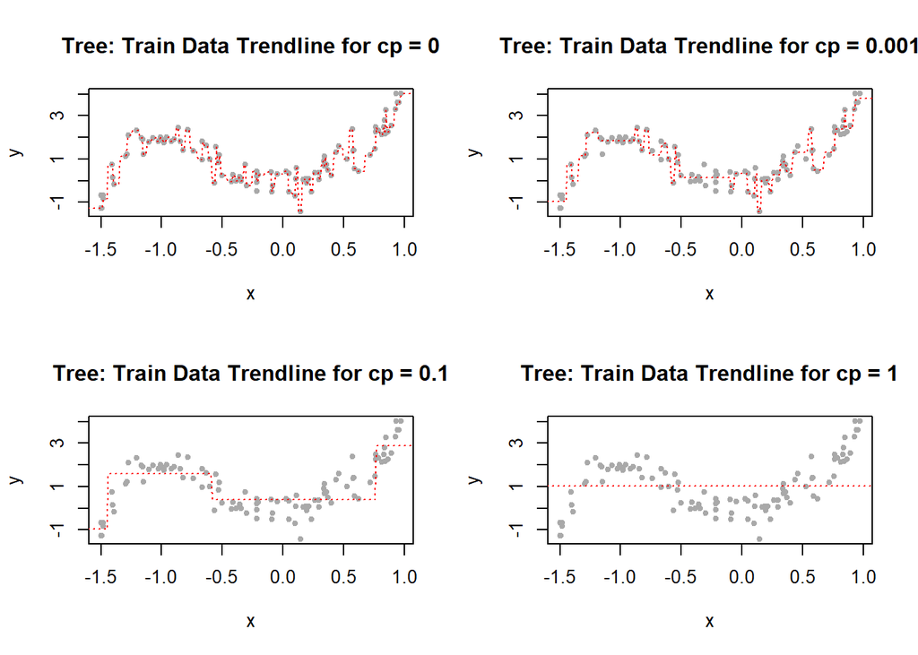

```r
tree_plot = function(cp){
  temp_grid = data.frame(x = seq(from = min(hw01_trn_data$x) - 5, to = max(hw01_trn_data$x) + 5, by  = 0.01))
  fit = rpart(y ~ x, data = hw01_trn_data, control = rpart.control(cp = cp, minsplit = 2))
  predict1 = predict(fit,temp_grid['x'])
  plot(y ~ x, data = hw01_trn_data, col = "darkgrey", pch = 20,main = gsub('this',cp,"Tree: Train Data Trendline for cp = this"))
  lines(temp_grid$x,predict1, col = 'red',lty = 3)
}
par(mfrow = c(2, 2))
tree_plot(0)
tree_plot(0.001)
tree_plot(0.1)
tree_plot(1)
```

When cp = 0 or 0.001, the model does not look good and likely to have an issue of overfitting. Whereas, the model of cp = 0.1 or 1 is facing the issue of underfitting.